# Fraud Detection on Imbalanced Transaction Data

**Objective:** Build a machine learning pipeline that detects fraudulent credit card transactions, treating class imbalance as the central challenge rather than an afterthought.

**Dataset:** `credit_card_fraud_10k.csv` — 10,000 transactions with 8 features (amount, hour, merchant category, foreign-transaction flag, location-mismatch flag, device trust score, 24h transaction velocity, cardholder age) and a binary `is_fraud` label.

## 1. Load Data & Analyse Class Imbalance

```python
import pandas as pd
import numpy as np
import matplotlib.pyplot as plt
import seaborn as sns
from sklearn.model_selection import train_test_split
from sklearn.preprocessing import StandardScaler
from sklearn.linear_model import LogisticRegression
from sklearn.ensemble import RandomForestClassifier
from sklearn.metrics import (precision_score, recall_score, f1_score, roc_auc_score,
                              roc_curve, classification_report, confusion_matrix, accuracy_score)
from imblearn.over_sampling import SMOTE

sns.set_theme(style="whitegrid", palette="deep")
plt.rcParams['figure.figsize'] = (9, 5)
pd.set_option('display.max_columns', None)

df = pd.read_csv('credit_card_fraud_10k.csv')
print(f"Shape: {df.shape[0]:,} rows x {df.shape[1]} columns")
df.head()
```

```
Shape: 10,000 rows x 10 columns
```

|  | transaction_id | amount | transaction_hour | merchant_category | foreign_transaction | location_mismatch | device_trust_score | velocity_last_24h | cardholder_age | is_fraud |
| --- | --- | --- | --- | --- | --- | --- | --- | --- | --- | --- |
| 0 | 1 | 84.47 | 22 | Electronics | 0 | 0 | 66 | 3 | 40 | 0 |
| 1 | 2 | 541.82 | 3 | Travel | 1 | 0 | 87 | 1 | 64 | 0 |
| 2 | 3 | 237.01 | 17 | Grocery | 0 | 0 | 49 | 1 | 61 | 0 |
| 3 | 4 | 164.33 | 4 | Grocery | 0 | 1 | 72 | 3 | 34 | 0 |
| 4 | 5 | 30.53 | 15 | Food | 0 | 0 | 79 | 0 | 44 | 0 |

```python
print("Column dtypes:")
print(df.dtypes)
print()
print(f"Missing values: {df.isnull().sum().sum()}")
print(f"Duplicate rows: {df.duplicated().sum()}")
```

```
Column dtypes:
transaction_id           int64
amount                 float64
transaction_hour         int64
merchant_category          str
foreign_transaction      int64
location_mismatch        int64
device_trust_score       int64
velocity_last_24h        int64
cardholder_age           int64
is_fraud                 int64
dtype: object

Missing values: 0
Duplicate rows: 0
```

```python
fraud_counts = df['is_fraud'].value_counts()
fraud_pct = df['is_fraud'].value_counts(normalize=True) * 100

print("Class counts:")
print(fraud_counts)
print()
print(f"Fraudulent transactions: {fraud_counts[1]} out of {len(df):,} ({fraud_pct[1]:.2f}%)")
print(f"Legitimate transactions: {fraud_counts[0]:,} ({fraud_pct[0]:.2f}%)")
```

```
Class counts:
is_fraud
0    9849
1     151
Name: count, dtype: int64

Fraudulent transactions: 151 out of 10,000 (1.51%)
Legitimate transactions: 9,849 (98.49%)
```

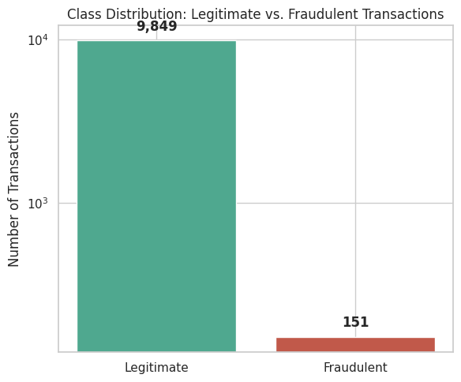

```python
plt.figure(figsize=(6, 5))
colors = ['#4FA88F', '#C1594A']
plt.bar(['Legitimate', 'Fraudulent'], fraud_counts.values, color=colors)
plt.title('Class Distribution: Legitimate vs. Fraudulent Transactions')
plt.ylabel('Number of Transactions')
plt.yscale('log')
for i, v in enumerate(fraud_counts.values):
    plt.text(i, v * 1.15, f'{v:,}', ha='center', fontweight='bold')
plt.tight_layout()
plt.show()
```

**Observation:** only **1.51% of transactions are fraudulent** (151 out of 10,000) — a severe, realistic class imbalance (log scale used above just to make the fraud bar visible at all next to the legitimate bar). This ~65:1 imbalance ratio is the central challenge of the entire task and shapes every modelling decision from here on.

## 2. Exploratory Data Analysis

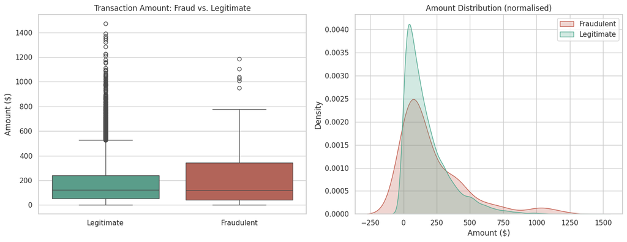

```
           count    mean     std   min    25%     50%     75%      max
is_fraud
0         9849.0  175.33  173.99  0.00  50.99  122.11  241.65  1471.04
1          151.0  216.18  248.12  0.11  41.53  118.94  341.70  1185.07
```

```python
fig, axes = plt.subplots(1, 2, figsize=(14, 5.5))

sns.boxplot(data=df, x='is_fraud', y='amount', ax=axes[0], palette=['#4FA88F', '#C1594A'])
axes[0].set_xticklabels(['Legitimate', 'Fraudulent'])
axes[0].set_title('Transaction Amount: Fraud vs. Legitimate')
axes[0].set_ylabel('Amount ($)')
axes[0].set_xlabel('')

sns.kdeplot(data=df, x='amount', hue='is_fraud', fill=True, common_norm=False,
            palette=['#4FA88F', '#C1594A'], ax=axes[1])
axes[1].set_title('Amount Distribution (normalised)')
axes[1].set_xlabel('Amount ($)')
axes[1].legend(['Fraudulent', 'Legitimate'])

plt.tight_layout()
plt.show()

print(df.groupby('is_fraud')['amount'].describe().round(2))
```

**Observation:** fraudulent transactions have a slightly higher mean amount ($216 vs. $175) but a much wider spread (std $248 vs. $174) and overlapping medians ($119 vs. $122) — amount alone is **not** a strong standalone discriminator here; fraud happens across the full range of transaction sizes, not just large ones.

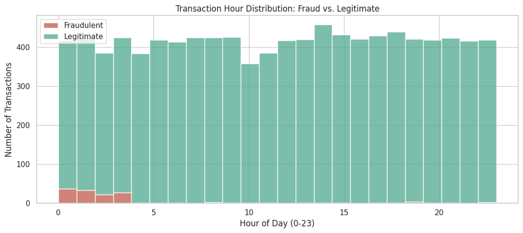

```
Fraud count by hour (top 6 hours):
transaction_hour
0     37
1     34
3     27
2     23
19     4
8      3
Name: count, dtype: int64
```

```python
plt.figure(figsize=(11, 5))
sns.histplot(data=df, x='transaction_hour', hue='is_fraud', bins=24, multiple='stack',
             palette=['#4FA88F', '#C1594A'])
plt.title('Transaction Hour Distribution: Fraud vs. Legitimate')
plt.xlabel('Hour of Day (0-23)')
plt.ylabel('Number of Transactions')
plt.legend(['Fraudulent', 'Legitimate'])
plt.tight_layout()
plt.show()

fraud_by_hour = df[df['is_fraud']==1]['transaction_hour'].value_counts().sort_index()
print("Fraud count by hour (top 6 hours):")
print(fraud_by_hour.sort_values(ascending=False).head(6))
```

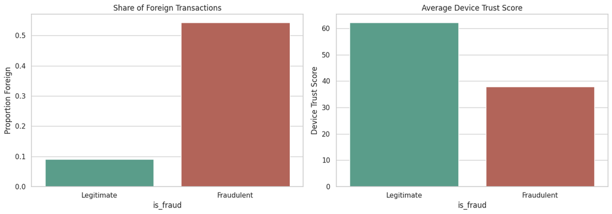

```
Foreign transaction rate: {0: 0.091, 1: 0.543}
Location mismatch rate: {0: 0.08, 1: 0.477}
Average device trust score: {0: 62.2, 1: 37.9}
Average 24h velocity: {0: 1.99, 1: 3.21}
```

```python
fig, axes = plt.subplots(1, 2, figsize=(14, 5))

sns.barplot(data=df, x='is_fraud', y='foreign_transaction', ax=axes[0], palette=['#4FA88F', '#C1594A'], errorbar=None)
axes[0].set_xticklabels(['Legitimate', 'Fraudulent'])
axes[0].set_title('Share of Foreign Transactions')
axes[0].set_ylabel('Proportion Foreign')

sns.barplot(data=df, x='is_fraud', y='device_trust_score', ax=axes[1], palette=['#4FA88F', '#C1594A'], errorbar=None)
axes[1].set_xticklabels(['Legitimate', 'Fraudulent'])
axes[1].set_title('Average Device Trust Score')
axes[1].set_ylabel('Device Trust Score')

plt.tight_layout()
plt.show()

print("Foreign transaction rate:", df.groupby('is_fraud')['foreign_transaction'].mean().round(3).to_dict())
print("Location mismatch rate:", df.groupby('is_fraud')['location_mismatch'].mean().round(3).to_dict())
print("Average device trust score:", df.groupby('is_fraud')['device_trust_score'].mean().round(1).to_dict())
print("Average 24h velocity:", df.groupby('is_fraud')['velocity_last_24h'].mean().round(2).to_dict())
```

**Observation:** these four features show dramatic separation between classes — fraudulent transactions are **foreign 54% of the time vs. 9% for legitimate ones**, show a **location mismatch 48% of the time vs. 8%**, come from devices with a much **lower average trust score (37.9 vs. 62.2)**, and show **higher 24h transaction velocity (3.2 vs. 2.0)**. These behavioural/contextual features, not transaction amount, are where the real predictive signal lives in this dataset.

## 3. Why Standard Accuracy Is a Misleading Metric Here

Consider a trivial "model" that **always predicts every transaction as legitimate**, never flagging a single fraud case. Its accuracy would be:

```python
baseline_accuracy = 1 - df['is_fraud'].mean()
print(f"Accuracy of a model that never predicts fraud: {baseline_accuracy:.4f} ({baseline_accuracy*100:.2f}%)")
```

```
Accuracy of a model that never predicts fraud: 0.9849 (98.49%)
```

**This "do-nothing" model scores 98.49% accuracy while catching zero fraud** — the single most important failure mode a fraud detection system exists to prevent. This happens precisely because accuracy weighs every correct prediction equally, and with a 65:1 class ratio, getting the *majority* class right on autopilot is nearly free.

This is why the rest of this notebook evaluates models using **precision, recall, F1-score, and AUC-ROC** instead of leading with accuracy — accuracy is reported alongside them for context, but never as the primary metric a model is judged on. A fraud detection system's entire value proposition is catching the rare positive class; a metric that can be gamed by ignoring that class entirely is not fit for purpose here.

## 4. Handling Class Imbalance: SMOTE

**SMOTE (Synthetic Minority Oversampling Technique)** generates new, synthetic fraud examples by interpolating between existing fraud cases and their nearest fraud neighbours in feature space — rather than simply duplicating existing minority rows (which would just make a model memorise the same 151 points harder), it creates plausible new points along the same regions of feature space where fraud already occurs.

**Critical detail — SMOTE is applied to the training set only, after the train/test split**, never before. Applying it before splitting would leak synthetic points derived from what should be unseen test fraud cases into the training set (via their nearest neighbours), inflating evaluation scores artificially. The test set is left in its original, real-world imbalanced state throughout, since that's what the model will actually face in deployment.

## 5. Encoding & Stratified Train/Test Split

```python
df_encoded = pd.get_dummies(df, columns=['merchant_category'], drop_first=True)

X = df_encoded.drop(columns=['transaction_id', 'is_fraud'])
y = df_encoded['is_fraud']

print(f"Feature columns ({len(X.columns)}): {X.columns.tolist()}")
```

```
Feature columns (11): ['amount', 'transaction_hour', 'foreign_transaction', 'location_mismatch', 'device_trust_score', 'velocity_last_24h', 'cardholder_age', 'merchant_category_Electronics', 'merchant_category_Food', 'merchant_category_Grocery', 'merchant_category_Travel']
```

```python
X_train, X_test, y_train, y_test = train_test_split(
    X, y, test_size=0.2, random_state=42, stratify=y
)

print(f"Training set: {len(X_train):,} transactions, {y_train.sum()} fraud ({y_train.mean()*100:.2f}%)")
print(f"Test set:     {len(X_test):,} transactions, {y_test.sum()} fraud ({y_test.mean()*100:.2f}%)")
```

```
Training set: 8,000 transactions, 121 fraud (1.51%)
Test set:     2,000 transactions, 30 fraud (1.50%)
```

**Observation:** stratification keeps the fraud rate nearly identical in both splits (~1.5%), and critically **both splits contain actual fraud cases** (121 in train, 30 in test) rather than risking an unlucky split that puts most or all fraud cases in only one side.

```python
scaler = StandardScaler()
X_train_scaled = scaler.fit_transform(X_train)
X_test_scaled = scaler.transform(X_test)

sm = SMOTE(random_state=42)
X_train_resampled, y_train_resampled = sm.fit_resample(X_train_scaled, y_train)

print(f"Before SMOTE: {pd.Series(y_train).value_counts().to_dict()}")
print(f"After SMOTE:  {pd.Series(y_train_resampled).value_counts().to_dict()}")
print(f"Test set (untouched): {pd.Series(y_test).value_counts().to_dict()}")
```

```
Before SMOTE: {0: 7879, 1: 121}
After SMOTE:  {0: 7879, 1: 7879}
Test set (untouched): {0: 1970, 1: 30}
```

## 6. Training Two Classifiers

- **Logistic Regression** — a fast, interpretable linear baseline; its coefficients directly show each feature's direction and strength of effect on fraud odds.
- **Random Forest** — a non-linear ensemble that can capture interactions between features (e.g. "foreign AND low trust score AND high velocity" being far more suspicious than any single flag alone).

Both are trained on the SMOTE-resampled training set, then evaluated on the original, untouched, realistically-imbalanced test set.

```python
lr_model = LogisticRegression(max_iter=1000, random_state=42)
lr_model.fit(X_train_resampled, y_train_resampled)
lr_pred = lr_model.predict(X_test_scaled)
lr_proba = lr_model.predict_proba(X_test_scaled)[:, 1]

rf_model = RandomForestClassifier(n_estimators=200, random_state=42)
rf_model.fit(X_train_resampled, y_train_resampled)
rf_pred = rf_model.predict(X_test_scaled)
rf_proba = rf_model.predict_proba(X_test_scaled)[:, 1]

print("Both models trained.")
```

```
Both models trained.
```

## 7. Evaluation: Precision, Recall, F1, and AUC-ROC

```python
def evaluate(name, y_true, y_pred, y_proba):
    acc = accuracy_score(y_true, y_pred)
    prec = precision_score(y_true, y_pred)
    rec = recall_score(y_true, y_pred)
    f1 = f1_score(y_true, y_pred)
    auc = roc_auc_score(y_true, y_proba)
    print(f"=== {name} ===")
    print(f"Accuracy:  {acc:.4f}  (shown for context only, not for judging the model)")
    print(f"Precision: {prec:.4f}")
    print(f"Recall:    {rec:.4f}")
    print(f"F1-score:  {f1:.4f}")
    print(f"AUC-ROC:   {auc:.4f}")
    print()
    print(classification_report(y_true, y_pred, target_names=['Legitimate', 'Fraud'], zero_division=0))
    return {'Model': name, 'Accuracy': acc, 'Precision': prec, 'Recall': rec, 'F1': f1, 'AUC-ROC': auc}

lr_metrics = evaluate("Logistic Regression", y_test, lr_pred, lr_proba)
rf_metrics = evaluate("Random Forest", y_test, rf_pred, rf_proba)
```

```
=== Logistic Regression ===
Accuracy:  0.9645  (shown for context only, not for judging the model)
Precision: 0.2887
Recall:    0.9333
F1-score:  0.4409
AUC-ROC:   0.9933

              precision    recall  f1-score   support

  Legitimate       1.00      0.96      0.98      1970
       Fraud       0.29      0.93      0.44        30

    accuracy                           0.96      2000
   macro avg       0.64      0.95      0.71      2000
weighted avg       0.99      0.96      0.97      2000

=== Random Forest ===
Accuracy:  0.9930  (shown for context only, not for judging the model)
Precision: 0.7857
Recall:    0.7333
F1-score:  0.7586
AUC-ROC:   0.9982

              precision    recall  f1-score   support

  Legitimate       1.00      1.00      1.00      1970
       Fraud       0.79      0.73      0.76        30

    accuracy                           0.99      2000
   macro avg       0.89      0.87      0.88      2000
weighted avg       0.99      0.99      0.99      2000
```

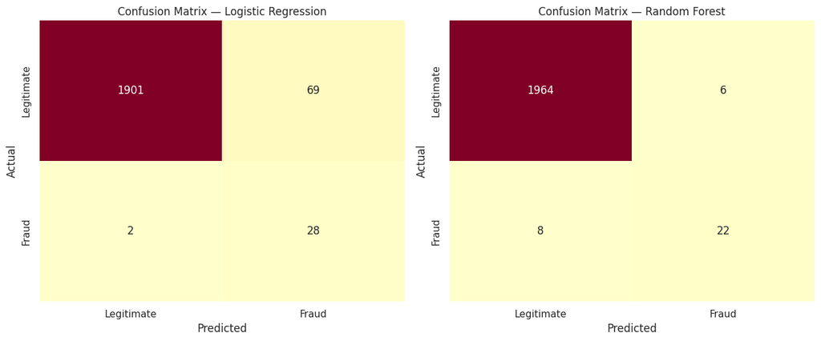

```python
fig, axes = plt.subplots(1, 2, figsize=(13, 5.5))

for ax, (name, preds) in zip(axes, [('Logistic Regression', lr_pred), ('Random Forest', rf_pred)]):
    cm = confusion_matrix(y_test, preds)
    sns.heatmap(cm, annot=True, fmt='d', cmap='YlOrRd', xticklabels=['Legitimate','Fraud'],
                yticklabels=['Legitimate','Fraud'], cbar=False, ax=ax)
    ax.set_title(f'Confusion Matrix — {name}')
    ax.set_xlabel('Predicted')
    ax.set_ylabel('Actual')

plt.tight_layout()
plt.show()
```

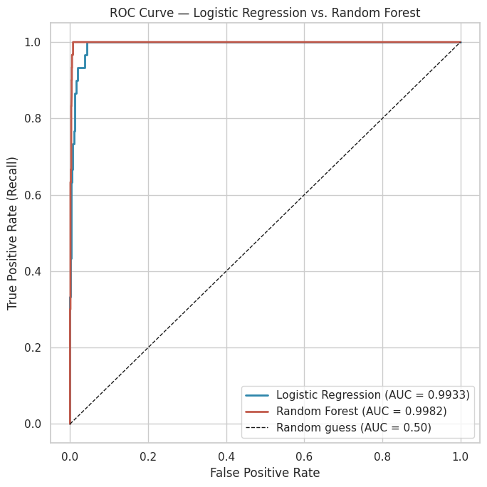

```python
plt.figure(figsize=(7, 7))

for name, proba, color in [('Logistic Regression', lr_proba, '#2E86AB'), ('Random Forest', rf_proba, '#C1594A')]:
    fpr, tpr, _ = roc_curve(y_test, proba)
    auc = roc_auc_score(y_test, proba)
    plt.plot(fpr, tpr, label=f'{name} (AUC = {auc:.4f})', linewidth=2, color=color)

plt.plot([0, 1], [0, 1], 'k--', linewidth=1, label='Random guess (AUC = 0.50)')
plt.xlabel('False Positive Rate')
plt.ylabel('True Positive Rate (Recall)')
plt.title('ROC Curve — Logistic Regression vs. Random Forest')
plt.legend()
plt.tight_layout()
plt.show()
```

**Observation:** the two models tell very different stories despite both being trained the same way.

- **Logistic Regression** catches **93% of fraud (recall)** but at the cost of very low precision (29%) — it flags roughly 3 legitimate transactions as fraud for every 1 real fraud case it correctly catches (69 false positives vs. 28 true positives).
- **Random Forest** is far more balanced: **73% recall at 79% precision** — it misses more fraud (8 of 30) but is right the large majority of the time when it does raise an alarm (only 6 false positives).
- Both models have excellent **AUC-ROC** (0.993 and 0.998 respectively), meaning both rank fraud cases as riskier than legitimate ones almost perfectly — the difference between them is really about **where the classification threshold is set and how each model's probability outputs are distributed**, not raw discriminative ability.

## 8. Which Metric Matters Most for Fraud Detection?

**The honest answer: it depends on the cost structure of the business, but recall is usually weighted more heavily than precision — up to a point.**

- **A false negative** (fraud that slips through undetected) means the cardholder or the bank absorbs a real financial loss, and the fraudulent pattern goes uncaught and can repeat.
- **A false positive** (a legitimate transaction flagged as fraud) costs a customer-service review, a possibly-declined purchase, and some customer annoyance — real, but generally far cheaper than an actual fraud loss.

This asymmetry is why **recall is usually the metric fraud teams protect first** — missing fraud is the more expensive mistake. This is exactly why Logistic Regression's 93% recall is genuinely valuable *despite* its low precision: in a real deployment, its output would typically feed a **secondary review queue** (a human analyst or a stricter second-stage model) rather than auto-declining every flagged transaction, making the false-positive cost more tolerable than it looks in isolation.

That said, **precision cannot be ignored entirely** — at Logistic Regression's precision level (29%), a bank processing millions of transactions would flood its fraud review team with false alarms, burning out analysts and slowing down legitimate customers at scale. **Random Forest's more balanced precision/recall trade-off (79% / 73%) is likely the more operationally realistic choice** for a system that auto-declines or holds transactions without human review, while Logistic Regression's high-recall profile is better suited as a wide first-pass filter ahead of a more precise second stage.

## 9. Feature Importance & Coefficient Analysis

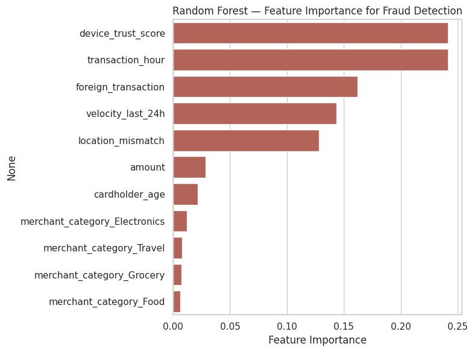

```
device_trust_score               0.241657
transaction_hour                 0.241597
foreign_transaction              0.161940
velocity_last_24h                0.143229
location_mismatch                0.127993
amount                           0.028606
cardholder_age                   0.021527
merchant_category_Electronics    0.012367
merchant_category_Travel         0.007723
merchant_category_Grocery        0.007270
merchant_category_Food           0.006091
dtype: float64
```

```python
importances = pd.Series(rf_model.feature_importances_, index=X.columns).sort_values(ascending=False)

plt.figure(figsize=(8, 6))
sns.barplot(x=importances.values, y=importances.index, color='#C1594A')
plt.xlabel('Feature Importance')
plt.title('Random Forest — Feature Importance for Fraud Detection')
plt.tight_layout()
plt.show()

importances
```

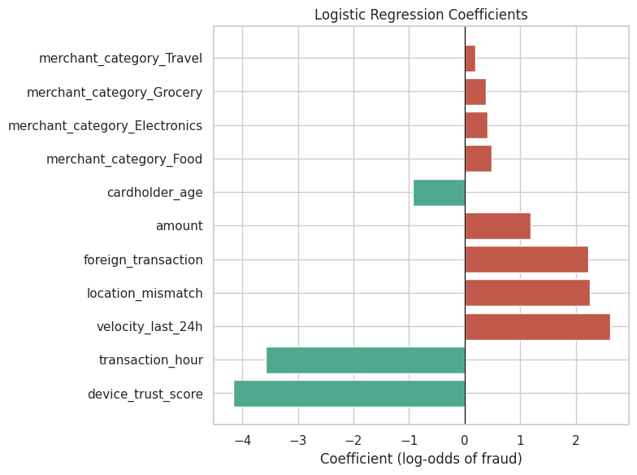

```
device_trust_score              -4.168336
transaction_hour                -3.572290
velocity_last_24h                2.618176
location_mismatch                2.251883
foreign_transaction              2.220424
amount                           1.185494
cardholder_age                  -0.926353
merchant_category_Food           0.482901
merchant_category_Electronics    0.417398
merchant_category_Grocery        0.391301
merchant_category_Travel         0.200958
dtype: float64
```

```python
coefficients = pd.Series(lr_model.coef_[0], index=X.columns).sort_values(key=abs, ascending=False)

plt.figure(figsize=(8, 6))
colors_coef = ['#4FA88F' if c < 0 else '#C1594A' for c in coefficients.values]
plt.barh(coefficients.index, coefficients.values, color=colors_coef)
plt.axvline(x=0, color='black', linewidth=0.8)
plt.xlabel('Coefficient (log-odds of fraud)')
plt.title('Logistic Regression Coefficients')
plt.tight_layout()
plt.show()

coefficients
```

**Observation:** both models agree closely on what matters — **`device_trust_score`** (strong negative coefficient / top importance — lower trust means higher fraud odds), **`transaction_hour`** (negative coefficient — later/earlier hour numbers near midnight increase fraud odds, consistent with the overnight concentration found in Section 2), **`foreign_transaction`**, **`location_mismatch`**, and **`velocity_last_24h`** (all positive — each raises fraud odds). This agreement between a linear model's coefficients and a non-linear model's importances, both matching the raw EDA patterns from Section 2, gives real confidence that these five features are the genuine drivers of fraud in this data — not an artifact of one particular algorithm.

## 10. Scalability: Handling 1 Million Transactions per Hour

**In short:** the modelling approach here is sound and would transfer conceptually, but moving from a notebook to 1M transactions/hour is primarily an **infrastructure and systems-engineering problem** (streaming features, tiered low-latency serving, async scoring, continuous retraining) layered on top of the same core algorithms, not a fundamentally different modelling problem.

## 11. Conclusion

**Fraud detection is a genuinely different problem from typical classification** because the metric that matters (catching rare, costly fraud) is exactly the metric standard accuracy hides. This notebook: confirmed the dataset's severe 1.51% imbalance; showed why accuracy alone would let a "do-nothing" model pass as 98.5% accurate; used SMOTE — applied correctly, after the split, to the training data only — to give both models a fair chance to learn the minority class; and compared two models with very different precision/recall trade-offs (Logistic Regression: high recall, low precision; Random Forest: balanced, higher F1 and AUC).

**For deployment, the choice between them is really a business decision about the cost of false positives vs. false negatives** — not a question with one universally correct answer, which is itself the most important lesson this dataset teaches.